# cm014 Worksheet: The Model-Fitting Paradigm in R

`broom` package makes tidy the output of base R model fitting options

```r
suppressPackageStartupMessages(library(tidyverse))
library(gapminder)
library(broom)
```

So you want to fit a model to your data. How can you achieve this with R?

Topics:

1. What *is* model-fitting?
2. How do we fit a model in R?
3. How can we obtain tidy results from the model output?

## What is Model-Fitting?

When variables are not independent, then we can gain information about one variable if we know something about the other.

Examples: Use the scatterplot below:

1. A car weighs 4000 lbs. What can we say about its mpg?
2. A car weights less than 3000 lbs. What can we say about its mpg?

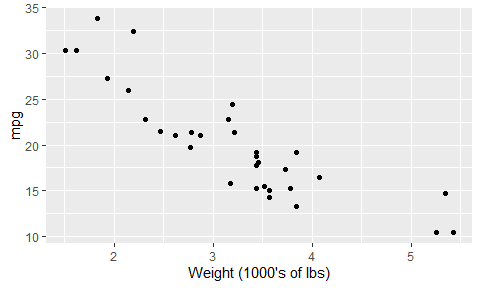

```r
library(tidyverse)

ggplot(mtcars, aes(wt, mpg)) +
  geom_point() +
  labs(x = "Weight (1000's of lbs)")
```

Example: What can we say about rear axle ratio if we know something about quarter mile time?

```r
?mtcars
```

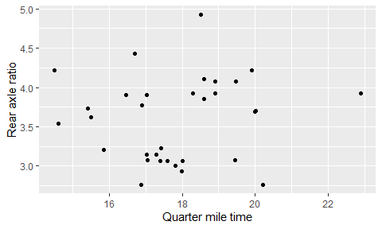

```r
ggplot(mtcars, aes(qsec, drat)) +
  geom_point() +
  labs(x = "Quarter mile time",
       y = "Rear axle ratio")
```

If EDA isn’t enough, we can answer these questions by fitting a model: a curve that predicts Y given X. Aka, a **regression curve** or a **machine learning model**.

(There are more comprehensive models too, such as modelling entire distributions, but that’s not what we’re doing here)

There are typically two goals of fitting a model:

1. Make predictions.
2. Interpret variable relationships.

## Fitting a model in R

Model fitting methods tend to use a common format in R:

```
method(formula, data, options)
```

They also tend to have a common output: a special *list*.

#### **Method**:

A function such as:

- Linear Regression: `lm`
- Generalized Linear Regression: `glm`
- Local regression: `loess`
- Quantile regression: `quantreg::rq`
- …

#### **Formula**:

In R, takes the form `y ~ x1 + x2 + ... + xp` (use column names in your data frame).

#### **Data**: The data frame.

#### **Options**: Specific to the method.

#### Exercise:

1. Fit a linear regression model to life expectancy (“Y”) from year (“X”) by filling in the formula. Notice what appears as the output.
2. On a new line, use the `unclass` function to uncover the object’s true nature: a list.
- Note: it might be easier to use the `names` function to see what components are included in the list.

First, create a subset of the `gapminder` dataset containing only the country of `France

```r
(gapminder_France <- FILL_THIS_IN)
```

```r
gapminder_France <- gapminder %>%
   filter(country == "France")
head(gapminder_France)
```

| country | continent | year | lifeExp | pop | gdpPercap |
| --- | --- | --- | --- | --- | --- |
| France | Europe | 1952 | 67.41 | 42459667 | 7029.809 |
| France | Europe | 1957 | 68.93 | 44310863 | 8662.835 |
| France | Europe | 1962 | 70.51 | 47124000 | 10560.486 |
| France | Europe | 1967 | 71.55 | 49569000 | 12999.918 |
| France | Europe | 1972 | 72.38 | 51732000 | 16107.192 |
| France | Europe | 1977 | 73.83 | 53165019 | 18292.635 |

Now, using the `lm()` function we will create the linear model

```r
(my_lm <- lm(FILL_THIS_IN))
```

```r
str(gapminder)
```

```
Classes ‘tbl_df’, ‘tbl’ and 'data.frame':   1704 obs. of  6 variables:
 $ country  : Factor w/ 142 levels "Afghanistan",..: 1 1 1 1 1 1 1 1 1 1 ...
 $ continent: Factor w/ 5 levels "Africa","Americas",..: 3 3 3 3 3 3 3 3 3 3 ...
 $ year     : int  1952 1957 1962 1967 1972 1977 1982 1987 1992 1997 ...
 $ lifeExp  : num  28.8 30.3 32 34 36.1 ...
 $ pop      : int  8425333 9240934 10267083 11537966 13079460 14880372 12881816 13867957 16317921 22227415 ...
 $ gdpPercap: num  779 821 853 836 740 ...
```

```r
(my_lm <- lm(lifeExp~year, data = gapminder))
```

```
Call:
lm(formula = lifeExp ~ year, data = gapminder)

Coefficients:
(Intercept)         year
  -585.6522       0.3259
```

```r
# Y ~ X means to fit Y according to Y
```

We are interested in the modeling results around the modeling period which starts at year 1952. To get a meaniningful “interpretable” intercept we can use the `I()` function.

```r
(my_lm <- lm(FILL_THIS_IN))
```

```r
(my_lm <- lm(lifeExp~I(year-1952), data = gapminder))
```

```
Call:
lm(formula = lifeExp ~ I(year - 1952), data = gapminder)

Coefficients:
   (Intercept)  I(year - 1952)
       50.5121          0.3259
```

```r
# I() changes interpreation of arithmetic symbols  from formula to operations
```

Use the `unclass()` function to take a look at how the `lm()` object actually looks like.

```r
unclass(my_lm)
```

[output not shown]

To complicate things further, some info is stored in *another* list after applying the `summary` function:

```r
summary(my_lm)
```

```
Call:
lm(formula = lifeExp ~ I(year - 1952), data = gapminder)

Residuals:
    Min      1Q  Median      3Q     Max
-39.949  -9.651   1.697  10.335  22.158

Coefficients:
               Estimate Std. Error t value
(Intercept)    50.51208    0.53000   95.31
I(year - 1952)  0.32590    0.01632   19.96
               Pr(>|t|)
(Intercept)      <2e-16 ***
I(year - 1952)   <2e-16 ***
---
Signif. codes:
0 ‘***’ 0.001 ‘**’ 0.01 ‘*’ 0.05 ‘.’ 0.1 ‘ ’ 1

Residual standard error: 11.63 on 1702 degrees of freedom
Multiple R-squared:  0.1898,    Adjusted R-squared:  0.1893
F-statistic: 398.6 on 1 and 1702 DF,  p-value: < 2.2e-16
```

We can use the `predict()` function to make predictions from the model (default is to use fitting/training data). Here are the predictions:

```r
predict(my_lm) %>%
  head()
```

```
       1        2        3        4        5
50.51208 52.14160 53.77112 55.40064 57.03016
       6
58.65968
```

Or we can predict on a new dataset:

```r
years1 =  data.frame(
  year=seq(2000,2010))%>% as_tibble()

predict(my_lm,years1)
```

```
       1        2        3        4        5
66.15547 66.48137 66.80728 67.13318 67.45908
       6        7        8        9       10
67.78499 68.11089 68.43679 68.76270 69.08860
      11
69.41451
```

We can plot models (with one predictor/ X variable) using `ggplot2` through the `geom_smooth()` layer. Specifying `method="lm"` gives us the linear regression fit (but only visually!):

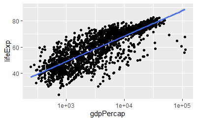

```r
ggplot(gapminder, aes(gdpPercap, lifeExp)) +
    geom_point() +
    geom_smooth(method="lm") +
    scale_x_log10()
```

Lets consider another country “Zimbabwe”, which has a unique behavior in the `lifeExp` and `year` relationship.

```r
gapminder_Zimbabwe <- FILL_THIS_IN

gapminder_Zimbabwe %>% ggplot(aes(year, lifeExp)) + geom_point()
```

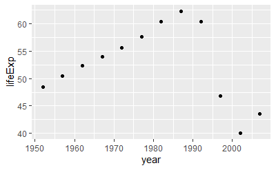

```r
gapminder_Zimbabwe <- gapminder %>%
  filter(country=="Zimbabwe")
gapminder_Zimbabwe %>% ggplot(aes(year, lifeExp)) + geom_point()
```

Let’s try fitting a linear model to this relationship

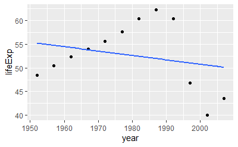

```r
ggplot(gapminder_Zimbabwe, aes(year,lifeExp)) +
  geom_point() +
  geom_smooth(method = "lm", se = F)
```

Now we will try to fit a second degree polynomial and see what would that look like.

```r
ggplot(FILL_THIS_IN) + geom_point()+geom_smooth(FILL_THIS_IN)
```

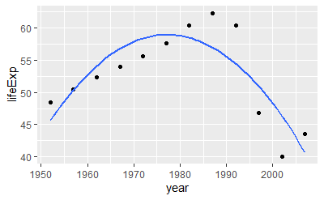

```r
ggplot(gapminder_Zimbabwe, aes(year, lifeExp)) + geom_point()+geom_smooth(method = "lm", se=F, formula = y ~ poly(x, 2) )
```

```r
# poly (x, #) creates a polynomial to the # degree of the X variable
```

```r
lm_linear <- lm(data = gapminder,formula = lifeExp~year)
lm_poly <- lm(data = gapminder,formula = lifeExp~poly(year, 2))
```

`anova` lets you compare between different models.

```r
anova(lm_linear,lm_poly)
```

```
Analysis of Variance Table

Model 1: lifeExp ~ year
Model 2: lifeExp ~ poly(year, 2)
  Res.Df    RSS Df Sum of Sq      F   Pr(>F)
1   1702 230229
2   1701 228793  1    1436.2 10.678 0.001106

1
2 **
---
Signif. codes:
0 ‘***’ 0.001 ‘**’ 0.01 ‘*’ 0.05 ‘.’ 0.1 ‘ ’ 1
```

## Regression with categorical variables

```r
(lm_cat <- lm(gdpPercap ~ I(year - 1952) + continent, data = gapminder))
```

```
Call:
lm(formula = gdpPercap ~ I(year - 1952) + continent, data = gapminder)

Coefficients:
      (Intercept)     I(year - 1952)
          -1375.3              129.8
continentAmericas      continentAsia
           4942.4             5708.4
  continentEurope   continentOceania
          12275.7            16427.9
```

How did R know that continent was a categorical variable? - *Based on the variable class (factor) and levels*

```r
class(gapminder$continent)
```

```
[1] "factor"
```

```r
levels(gapminder$continent)
```

```
[1] "Africa"   "Americas" "Asia"
[4] "Europe"   "Oceania"
```

```r
contrasts(gapminder$continent)
```

```
         Americas Asia Europe Oceania
Africa          0    0      0       0
Americas        1    0      0       0
Asia            0    1      0       0
Europe          0    0      1       0
Oceania         0    0      0       1
```

How can we change the reference level?

```r
gapminder$continent <- relevel(gapminder$continent, ref = "Oceania")
```

Let’s build a new model

```r
(lm_cat2 <- lm(gdpPercap ~ I(year - 1952) + continent, data = gapminder) )
```

```
Call:
lm(formula = gdpPercap ~ I(year - 1952) + continent, data = gapminder)

Coefficients:
      (Intercept)     I(year - 1952)
          15052.5              129.8
  continentAfrica  continentAmericas
         -16427.9           -11485.5
    continentAsia    continentEurope
         -10719.5            -4152.1
```

## Broom

Let’s make it easier to extract info, using the `broom` package. There are three crown functions in this package, all of which input a fitted model, and outputs a tidy data frame.

1. `tidy`: extract statistical summaries about each component of the model.
   - Useful for *interpretation* task.
2. `augment`: add columns to the original data frame, giving information corresponding to each row.
   - Useful for *prediction* task.
3. `glance`: extract statistical summaries about the model as a whole (1-row tibble).
   - Useful for checking goodness of fit.

Exercise: apply all three functions to our fitted model, `my_lm`. What do you see? - my_lm, model of `lifeExp ~ I(year-1952)`

[output not shown]

```r
tidy(my_lm)

augment(my_lm)
```

| lifeExp | I.year...1952. | .fitted | .se.fit | .resid | .hat | .sigma | .cooksd | .std.resid |
| --- | --- | --- | --- | --- | --- | --- | --- | --- |
| 28.80100 | 0 | 50.51208 | 0.5299963 | -21.71108411 | 0.0020765619 | 11.62203 | 3.633144e-03 | -1.868669402 |
| 30.33200 | 5 | 52.14160 | 0.4629044 | -21.80960324 | 0.0015840967 | 11.62193 | 2.793981e-03 | -1.876685922 |
| 31.99700 | 10 | 53.77112 | 0.4012330 | -21.77412238 | 0.0011901244 | 11.62197 | 2.090630e-03 | -1.873263287 |
| 34.02000 | 15 | 55.40064 | 0.3478771 | -21.38064152 | 0.0008946453 | 11.62241 | 1.514394e-03 | -1.839139469 |
| 36.08800 | 20 | 57.03016 | 0.3072006 | -20.94216066 | 0.0006976591 | 11.62288 | 1.132561e-03 | -1.801244264 |
| 38.43800 | 25 | 58.65968 | 0.2846912 | -20.22167980 | 0.0005991661 | 11.62363 | 9.067163e-04 | -1.739189687 |
| 39.85400 | 30 | 60.28920 | 0.2846912 | -20.43519894 | 0.0005991661 | 11.62341 | 9.259653e-04 | -1.757553655 |
| 40.82200 | 35 | 61.91872 | 0.3072006 | -21.09671807 | 0.0006976591 | 11.62271 | 1.149340e-03 | -1.814537813 |
| 41.67400 | 40 | 63.54824 | 0.3478771 | -21.87423721 | 0.0008946453 | 11.62187 | 1.585124e-03 | -1.881598032 |
| 41.76300 | 45 | 65.17776 | 0.4012330 | -23.41475635 | 0.0011901244 | 11.62010 | 2.417548e-03 | -2.014409705 |

[output cut: 990 more lines]

```r
glance(my_lm)
```

| r.squared | adj.r.squared | sigma | statistic | p.value | df | logLik | AIC | BIC | deviance | df.residual |
| --- | --- | --- | --- | --- | --- | --- | --- | --- | --- | --- |
| 0.1897571 | 0.1892811 | 11.63055 | 398.6047 | 7.546795e-80 | 2 | -6597.866 | 13201.73 | 13218.05 | 230229.2 | 1702 |